# Interview Project Submission (Business Owners Policies)

Nationwide Insurance Business Insights Team Daran Thach (job applicant) 6.29.22

The main objective is to discover the industry segments trending higher in Loss Ratios. From the data, propose a hypothesis why, and recommend a solution for it. In the investigation of the data, consider the following questions:

- Are certain segments performing markedly poorer than others? If so, hypothesize to why and propose a recommendation to fix.
- Is there a common story inherent in the data? What does this story tell at a high level? What should we do as a result?
- Are there areas or segments that produce strange results?
- What additional data do you wish you had?

# Summary of hypotheses and recommendations

1. There is a statistically significant relationship between loss incurred and loss ratio. As shown in the results below, there is a significant correlation between incurred loss and loss ratio, holding other variables to a normalized scale. Across all commercial lines, loss ratios have trended lower. The business lines underperforming in this metric are retail and warehouse segments, with habitational and food service segments performing better.

#### Recommendation: Monitor loss ratio as a function of differentiated claim type (liability, workers comp, property). This allows one to drill down which specific claims are incurring the heavier incurred loss. Underwrite coverage to adjust premiums up for retail and warehouse if seeking higher profitability. Consider raising deductibles for more frequent claims.

1. COVID-19 related factors possibly influenced the recent loss ratio performance. Without having more data such as reasons for new claim reasons (injury, accidents, lawsuits, property damage), we cannot correlate the magnitude of pandemic response to loss ratio. Visually, new claims did seem to rise with the brunt of COVID's onset in the spring of 2020, as shown in the 'new claims' chart of dashboard below:

https://public.tableau.com/views/TrendsforBOPData2019-Present/Dashboard1?:language=en-US&:display_count=n&:origin=viz_share_link

#### Recommend tracking reasons on new claims for added analysis. Consider underwriting premium increases, especially on casualty retail, should uncertainties last longer than expected. Expect demand to return as clients become more risk aware in the aftermath of the pandemic.

1. Monetary inflation influenced the downtrend of policies carried in 2022. It is likely that the forces of inflation and the higher cost of doing business led to decreased policy carrying. This is reflected in a few ways: a) insurer is decreasing its exposure to clients, b) businesses are cancelling or trimming down their policies, or c) business are closing due to rising costs. As an experiment, we consider the chart below, which shows a positive correlation between PCE (personal consumption expenditures) to the amount of commercial policies carried:

https://public.tableau.com/views/PersonalConsumerExpendituresPCEpricevsCommercialPoliciesCarried/Sheet2?:language=en-US&:display_count=n&:origin=viz_share_link

#### Recommend periodic monitoring of loss ratio figures. Maintain underwriting preference towards a higher premium, while being aware of deflationary risk. If new claims incur higher losses, be flexible by adjusting premiums up.

1. Weather events losses are discretely hidden in the findings. The dataset likely reflects weather event-related claims. When Texas had a statewide power outage from the ill-prepared winter freeze, this may have led to the spike of losses in 2021. Recommend analysis of property damage claims. Weather data centers can help provide real-time information to reduce extent of property damage. Coverages need to profitably share the amount of risk taken, but build trust with clients.

#### Recommend reducing the coverage differences for natural disasters and severe weather events. Coordinate alerting efforts with climate data centers. In times of weather distress, mitigate risk through diligent communication. Stay transparent in justifying premium adjustments or restrictions.

1. Cybersecurity breach losses are discretely hidden in the findings. Cybersecurity crime is becoming more commonplace for commercial entities, large or small. Underwriting should reflect the extent of damage potential for firms possessing large amounts of sensitive data.

#### Recommend analysis of property damage claims and underwrite according to amount of personal data stored. Stay transparent in justifying premium adjustments or restrictions.

# Objectives

The main objective is to discover the industry segments trending higher in Loss Ratios. Propose some hypotheses to why these trends exist, and recommend solutions for the Insights team.

1. Define the problem.
2. Design test, discover associations. -explore numeric data -explore categorical data
3. Test models from evaluation.
4. Summarize model for recommendations.

# Background

An insurance company's loss ratio shows the relationship between incurred losses and earned premiums. Insurance companies with very high loss ratios may need to raise premiums to stay solvent and ensure their ability to pay future claims. A very low loss ratio means that consumers are paying too much for the benefit received. A higher loss ratio means lower profits for the insurance company and is, therefore, a problem for underwriters and investors alike. Underwriters and investors use the loss ratio for various purposes. IL/EP *100 = Loss Ratio %.

High LRs risk being unable to meet future liability payments. Underwriters are particularly interested in the loss ratio. When the claims loss ratio is too high, either the premiums must rise or certain insured groups must be denied coverage. In the insurance industry, this is referred to as a hardening of the market. Investors are also interested in the loss ratio. They may use the combined loss ratio (both losses and expenses) as one of many metrics to compare insurance companies for investment decisions.

# 1. Define the problem

1. What are the inputs and outputs for a forecast? Time series (dates from 2019-2022), both structured (continuous numeric, categorical), partially unstructured data (years in business). Forecasting a time series may yield tremendous commercial value. Consider LR for multivariate time series forecasting.
2. Are you working on a regression or classification predictive modeling problem? Regression & Descriptive Models.
3. Are you working on a univariate or multivariate time series problem? Multivariate.
4. Do you require a single-step or a multi-step forecast? Multi-step to compare against numeric variables, then
5. Do you require a static or a dynamically updated model? Static for purposes of project.

```python
## Begin data analysis of R2 for Nationwide.
```

```python
# import numpy library
import numpy as np
# import pandas to read files
import pandas as pd
```

```python
# examine contents of dataset 'businessownerspolicy'.
df = pd.read_excel(r'C:\Users\daran\Documents\Resumes\Business Insights Specialist\BOPdataTableau.xlsx')
df.head()
```

|  | ACCOUNTING_MONTH | MARKET | NEW_RENEWAL_INDICATOR | INDUSTRY | MULTI_LINE_INDICATOR | Region | SUPER_REGION_CODE | DEDUCTIBLE_BUCKET | YEARS_IN_BUSINESS | PIF | DWP | EP | IL | NEW_CLAIMS | BUILDING_COUNT | BLDG_COVALIMIT | BLDG_COVBLIMIT |
| --- | --- | --- | --- | --- | --- | --- | --- | --- | --- | --- | --- | --- | --- | --- | --- | --- | --- |
| 0 | 201906 | Small | Renewal | Office | Multiline | NERO | EAST | 1000.0 | over 25 | 7 | 63925.0 | 54566.04 | 49655.00 | 1.0 | 267.0 | 188412965.0 | 41375100.0 |
| 1 | 201906 | Small | Renewal | Service | Monoline | NERO | EAST | 1000.0 | 2022-11-25 00:00:00 | 10 | 58176.0 | 49865.39 | NaN | NaN | 242.0 | 61781746.0 | 36672080.0 |
| 2 | 201906 | Small | Renewal | Office | Monoline | CARO | EAST | 1000.0 | 2022-04-10 00:00:00 | 2 | 5178.0 | 8359.42 | 1617.32 | 2.0 | 61.0 | 68027895.0 | 1159900.0 |
| 3 | 201906 | Small | Renewal | Service | MonoLine | NERO | EAST | 1000.0 | 2022-04-10 00:00:00 | 5 | 15222.0 | 26468.31 | NaN | NaN | 116.0 | 25631023.0 | 15458200.0 |
| 4 | 201906 | Small | Renewal | Warehouse | Multiline | NERO | EAST | 1000.0 | 2022-11-25 00:00:00 | 1 | 22464.0 | 9538.47 | NaN | NaN | 31.0 | 9895004.0 | 9433200.0 |

```python
# Describe the rows and columns in dataset
df.shape
```

```
(145651, 17)
```

```python
# Find output type in dataframe.
df.info()
```

```
<class 'pandas.core.frame.DataFrame'>
RangeIndex: 145651 entries, 0 to 145650
Data columns (total 17 columns):
 #   Column                 Non-Null Count   Dtype
---  ------                 --------------   -----
 0   ACCOUNTING_MONTH       145651 non-null  int64
 1   MARKET                 133080 non-null  object
 2   NEW_RENEWAL_INDICATOR  145388 non-null  object
 3   INDUSTRY               140427 non-null  object
 4   MULTI_LINE_INDICATOR   145651 non-null  object
 5   Region                 145651 non-null  object
 6   SUPER_REGION_CODE      145651 non-null  object
 7   DEDUCTIBLE_BUCKET      114729 non-null  float64
 8   YEARS_IN_BUSINESS      145651 non-null  object
 9   PIF                    145651 non-null  int64
 10  DWP                    145280 non-null  float64
 11  EP                     145280 non-null  float64
 12  IL                     21603 non-null   float64
 13  NEW_CLAIMS             21603 non-null   float64
 14  BUILDING_COUNT         145280 non-null  float64
 15  BLDG_COVALIMIT         135281 non-null  float64
 16  BLDG_COVBLIMIT         135281 non-null  float64
dtypes: float64(8), int64(2), object(7)
memory usage: 18.9+ MB
```

## 1a. Input considerations

Numeric variables

Does the numeric explanatory variables affect the response variable? Linear regression is a good model to consider. The coefficient of determination (R squared) describes the overall relationship between the independent variables X (deductibles, policies in force, earned premium) and the dependent variable Y (loss ratio). The regression coefficient (b) determines the overall positive/negative relationship. We need to find which variables can best explain the dependent variable. Our inference on the data parameters using hypothesis testing is:

H0. There is no significant relationship between the independent predictor (X1, X2, X3...) and dependent variable (Y); b=0. HA. There is a significant relationship between the independent predictor (X1, X2, X3...) and dependent variable (Y); b !=0.

Categorical variables

Categorical var: How are the segments related to the response variable, and to what extent? Typically we need to change the granularity of the variable to provide more generalizable results for LR. For at least one variable, may change granularity to fit into regression. For categorical independent variable industry, can assess trends visually distributed continuous as it relates to dependent variable, loss ratio.

# 2. Design test, discover associations in numeric data.

1. Describe and discover correlations with overall dataset.

```python
# Check for presence of null values. Consider that Incurred Loss & New Claims contain relatively few values.
df.isnull().head()
```

|  | ACCOUNTING_MONTH | MARKET | NEW_RENEWAL_INDICATOR | INDUSTRY | MULTI_LINE_INDICATOR | Region | SUPER_REGION_CODE | DEDUCTIBLE_BUCKET | YEARS_IN_BUSINESS | PIF | DWP | EP | IL | NEW_CLAIMS | BUILDING_COUNT | BLDG_COVALIMIT | BLDG_COVBLIMIT |
| --- | --- | --- | --- | --- | --- | --- | --- | --- | --- | --- | --- | --- | --- | --- | --- | --- | --- |
| 0 | False | False | False | False | False | False | False | False | False | False | False | False | False | False | False | False | False |
| 1 | False | False | False | False | False | False | False | False | False | False | False | False | True | True | False | False | False |
| 2 | False | False | False | False | False | False | False | False | False | False | False | False | False | False | False | False | False |
| 3 | False | False | False | False | False | False | False | False | False | False | False | False | True | True | False | False | False |
| 4 | False | False | False | False | False | False | False | False | False | False | False | False | True | True | False | False | False |

```python
# Convert column Accounting_Month to date using year, month in pandas
df['ACCOUNTING_MONTH'] = pd.to_datetime(df['ACCOUNTING_MONTH'], format='%Y%m', errors='coerce')
df['ACCOUNTING_MONTH']
```

```
0        2019-06-01
1        2019-06-01
2        2019-06-01
3        2019-06-01
4        2019-06-01
            ...
145646   2022-02-01
145647   2022-02-01
145648   2022-02-01
145649   2022-02-01
145650   2022-02-01
Name: ACCOUNTING_MONTH, Length: 145651, dtype: datetime64[ns]
```

```python
# Describe the numeric data to observe for normal distribution, outliers.
df.describe()
```

|  | DEDUCTIBLE_BUCKET | PIF | DWP | EP | IL | NEW_CLAIMS | BUILDING_COUNT | BLDG_COVALIMIT | BLDG_COVBLIMIT |
| --- | --- | --- | --- | --- | --- | --- | --- | --- | --- |
| count | 114729.000000 | 145651.000000 | 1.452800e+05 | 1.452800e+05 | 2.160300e+04 | 21603.000000 | 145280.000000 | 1.352810e+05 | 1.352810e+05 |
| mean | 1057.139145 | 6.865315 | 1.938707e+04 | 1.905224e+04 | 7.079163e+04 | 2.675508 | 102.230775 | 6.457937e+07 | 7.882151e+06 |
| std | 2323.861120 | 13.484508 | 7.658989e+04 | 7.163734e+04 | 3.674139e+05 | 3.860780 | 517.909186 | 2.732459e+08 | 2.824426e+07 |
| min | 0.000000 | 1.000000 | -3.741220e+05 | -4.878900e+04 | -5.274273e+04 | 1.000000 | 0.000000 | 0.000000e+00 | 0.000000e+00 |
| 25% | 0.000000 | 1.000000 | 0.000000e+00 | 3.058025e+02 | 3.062405e+03 | 1.000000 | 1.000000 | 7.099000e+05 | 1.200000e+05 |
| 50% | 250.000000 | 3.000000 | 0.000000e+00 | 1.675445e+03 | 1.208770e+04 | 1.000000 | 7.000000 | 4.279900e+06 | 7.146000e+05 |
| 75% | 1000.000000 | 8.000000 | 7.355000e+03 | 8.906872e+03 | 4.560697e+04 | 3.000000 | 38.000000 | 2.516380e+07 | 3.474100e+06 |
| max | 25000.000000 | 452.000000 | 2.968166e+06 | 2.058777e+06 | 4.296603e+07 | 92.000000 | 20953.000000 | 6.952358e+09 | 4.868656e+08 |

### Observation

DEDUCTIBLE_BUCKET, PIF, EP, IL, NEW_CLAIMS, BUILDING_COUNT, BLDG_COVALIMIT, & BLDG_COVBLIMIT have varying scales, non-normal distribution and large std deviations.

Recommend normalize data for distribution to perform linear regression model. This rescales the data from the original range so that all values are within the range of 0 and 1. This prevents the model from favoring values with a larger scale.

Normalization can be useful, and even required in some machine learning algorithms when your TS data has input values with differing scales. It may be required for algorithms, like k-Nearest neighbors, and Linear Regression. Use normalization when you don’t know the distribution of your data or you know it is not Gaussian.

```python
# Prepare normalization by removing 'ACCOUNTING_MONTH', 'YEARS_IN_BUSINESS' & CATEGORICAL columns from dataframe.
df_nodate = df.drop(['ACCOUNTING_MONTH', 'MARKET', 'NEW_RENEWAL_INDICATOR', 'INDUSTRY',
                     'MULTI_LINE_INDICATOR', 'Region', 'SUPER_REGION_CODE', 'YEARS_IN_BUSINESS'], axis =1)
print(df_nodate)
```

```
        DEDUCTIBLE_BUCKET  PIF      DWP        EP        IL  NEW_CLAIMS  \
0                  1000.0    7  63925.0  54566.04  49655.00         1.0
1                  1000.0   10  58176.0  49865.39       NaN         NaN
2                  1000.0    2   5178.0   8359.42   1617.32         2.0
3                  1000.0    5  15222.0  26468.31       NaN         NaN
4                  1000.0    1  22464.0   9538.47       NaN         NaN
...                   ...  ...      ...       ...       ...         ...
145646                0.0    4      0.0      0.00       NaN         NaN
145647             1000.0    1      0.0    311.76       NaN         NaN
145648              500.0    1      0.0    377.28       NaN         NaN
145649                0.0    1      0.0      0.00       NaN         NaN
145650                0.0    1      0.0   3814.36       NaN         NaN

        BUILDING_COUNT  BLDG_COVALIMIT  BLDG_COVBLIMIT
0                267.0     188412965.0      41375100.0
1                242.0      61781746.0      36672080.0
2                 61.0      68027895.0       1159900.0
3                116.0      25631023.0      15458200.0
4                 31.0       9895004.0       9433200.0
...                ...             ...             ...
145646             0.0             NaN             NaN
145647             1.0             0.0        113200.0
145648             1.0             0.0        185300.0
145649             0.0             NaN             NaN
145650             4.0      17315000.0       5255900.0

[145651 rows x 9 columns]
```

```python
# Import MinMaxScaler library.
from sklearn.preprocessing import MinMaxScaler
scaler = MinMaxScaler()
scaler.fit(df_nodate)
scaled = scaler.fit_transform(df_nodate)
scaled_df = pd.DataFrame(scaled, columns = df_nodate.columns)
```

```python
# See how normalized numeric data appears in dataframe 'scaled_df'.
print(scaled_df)
```

```
        DEDUCTIBLE_BUCKET       PIF       DWP        EP        IL  NEW_CLAIMS  \
0                    0.04  0.013304  0.131062  0.049040  0.002380    0.000000
1                    0.04  0.019956  0.129342  0.046810       NaN         NaN
2                    0.04  0.002217  0.113485  0.027116  0.001264    0.010989
3                    0.04  0.008869  0.116490  0.035708       NaN         NaN
4                    0.04  0.000000  0.118657  0.027675       NaN         NaN
...                   ...       ...       ...       ...       ...         ...
145646               0.00  0.006652  0.111936  0.023149       NaN         NaN
145647               0.04  0.000000  0.111936  0.023297       NaN         NaN
145648               0.02  0.000000  0.111936  0.023328       NaN         NaN
145649               0.00  0.000000  0.111936  0.023149       NaN         NaN
145650               0.00  0.000000  0.111936  0.024959       NaN         NaN

        BUILDING_COUNT  BLDG_COVALIMIT  BLDG_COVBLIMIT
0             0.012743        0.027101        0.084983
1             0.011550        0.008886        0.075323
2             0.002911        0.009785        0.002382
3             0.005536        0.003687        0.031750
4             0.001480        0.001423        0.019375
...                ...             ...             ...
145646        0.000000             NaN             NaN
145647        0.000048        0.000000        0.000233
145648        0.000048        0.000000        0.000381
145649        0.000000             NaN             NaN
145650        0.000191        0.002491        0.010795

[145651 rows x 9 columns]
```

```python
# Add 'ACCOUNTING_MONTH' back to dataframe, ordering date column first.
## Create the new series for target dependent variable (y), 'loss_ratio'.
scaled_df['DATE'] = df['ACCOUNTING_MONTH']
scaled_df['LOSS_RATIO'] = scaled_df['IL']/scaled_df['EP']
```

```python
# Initiate 'MARKET' as last variable to numeric dataframe, by changing granularity into binary 0/1.
## Designate 0 =  middle, 1 = small then drop 0 column.
mkttype = pd.get_dummies(df['MARKET'], prefix = 'SMALL_MARKET', drop_first = True)
mkttype.head()
```

|  | SMALL_MARKET_Small |
| --- | --- |
| 0 | 1 |
| 1 | 1 |
| 2 | 1 |
| 3 | 1 |
| 4 | 1 |

```python
# Add dummy 'mkttype' column to dataframe.
scaled_df['SMALL_MARKET'] = mkttype['SMALL_MARKET_Small']
```

```python
# Rearrange column index so date can become main index.
scaleddate_df = scaled_df[['DATE', 'SMALL_MARKET', 'BUILDING_COUNT', 'BLDG_COVALIMIT', 'BLDG_COVBLIMIT',
                           'DEDUCTIBLE_BUCKET', 'DWP', 'PIF', 'NEW_CLAIMS', 'IL', 'EP', 'LOSS_RATIO']]
print(scaleddate_df)
```

```
             DATE  SMALL_MARKET  BUILDING_COUNT  BLDG_COVALIMIT  \
0      2019-06-01             1        0.012743        0.027101
1      2019-06-01             1        0.011550        0.008886
2      2019-06-01             1        0.002911        0.009785
3      2019-06-01             1        0.005536        0.003687
4      2019-06-01             1        0.001480        0.001423
...           ...           ...             ...             ...
145646 2022-02-01             0        0.000000             NaN
145647 2022-02-01             1        0.000048        0.000000
145648 2022-02-01             1        0.000048        0.000000
145649 2022-02-01             0        0.000000             NaN
145650 2022-02-01             0        0.000191        0.002491

        BLDG_COVBLIMIT  DEDUCTIBLE_BUCKET       DWP       PIF  NEW_CLAIMS  \
0             0.084983               0.04  0.131062  0.013304    0.000000
```

[output cut: 25 more lines]

```python
# Set the 'DATE' as index to have oldest values at top.
scaleddate_df.set_index('DATE', inplace = True)
scaleddate_df.head(10)
```

| DATE | SMALL_MARKET | BUILDING_COUNT | BLDG_COVALIMIT | BLDG_COVBLIMIT | DEDUCTIBLE_BUCKET | DWP | PIF | NEW_CLAIMS | IL | EP | LOSS_RATIO |
| --- | --- | --- | --- | --- | --- | --- | --- | --- | --- | --- | --- |
| 2019-06-01 | 1 | 0.012743 | 0.027101 | 0.084983 | 0.04 | 0.131062 | 0.013304 | 0.000000 | 0.002380 | 0.049040 | 0.048538 |
| 2019-06-01 | 1 | 0.011550 | 0.008886 | 0.075323 | 0.04 | 0.129342 | 0.019956 | NaN | NaN | 0.046810 | NaN |
| 2019-06-01 | 1 | 0.002911 | 0.009785 | 0.002382 | 0.04 | 0.113485 | 0.002217 | 0.010989 | 0.001264 | 0.027116 | 0.046601 |
| 2019-06-01 | 1 | 0.005536 | 0.003687 | 0.031750 | 0.04 | 0.116490 | 0.008869 | NaN | NaN | 0.035708 | NaN |
| 2019-06-01 | 1 | 0.001480 | 0.001423 | 0.019375 | 0.04 | 0.118657 | 0.000000 | NaN | NaN | 0.027675 | NaN |
| 2019-06-01 | 1 | 0.020236 | 0.014003 | 0.132579 | 0.02 | 0.131862 | 0.026608 | NaN | NaN | 0.048094 | NaN |
| 2019-06-01 | 1 | 0.000095 | 0.000000 | 0.000086 | 0.02 | 0.111936 | 0.006652 | NaN | NaN | 0.023286 | NaN |
| 2019-06-01 | 1 | 0.002673 | 0.000276 | 0.012576 | 0.01 | 0.113941 | 0.002217 | NaN | NaN | 0.025865 | NaN |
| 2019-06-01 | 1 | 0.000859 | 0.000990 | 0.003831 | 0.04 | 0.114133 | 0.000000 | NaN | NaN | 0.025567 | NaN |
| 2019-06-01 | 1 | 0.006538 | 0.005454 | 0.055067 | 0.04 | 0.121310 | 0.008869 | 0.010989 | 0.003551 | 0.042283 | 0.083972 |

## 2.1 Discover correlations.

Dataset is sufficiently large, so efficient. Hopefully variance decreases as sample increases (consistent) and unbiased.

```python
## Observe correlations using matplotlib prior to training and modelling.
from sklearn.linear_model import LinearRegression
import matplotlib.pyplot as plt
```

[figure not shown]

```python
jet= plt.get_cmap('jet')
colors = iter(jet(np.linspace(0,1,10)))

def correlation(scaleddate_df,variables, n_rows, n_cols):
    fig = plt.figure(figsize=(14,9))

    for i, var in enumerate(variables):
        ax = fig.add_subplot(n_rows,n_cols,i+1)
        asset = scaleddate_df.loc[:,var]
        ax.scatter(scaleddate_df['LOSS_RATIO'], asset, color = next(colors))
        ax.set_xlabel("LOSS_RATIO")
        ax.set_ylabel("{}".format(var))
        ax.set_title(var +" VS LR")
    fig.tight_layout()
    plt.show()
# Use all variables except the last column, 'lOSS_RATIO'.
variables = scaleddate_df.columns[0:9]
correlation(scaleddate_df, variables, 4,3)
```

```python
# Apply correlation matrix between variables and target 'LOSS_RATIO'.
scaleddate_df.corr()['LOSS_RATIO'].loc[variables]
```

```
SMALL_MARKET        -0.026087
BUILDING_COUNT      -0.040758
BLDG_COVALIMIT      -0.040407
BLDG_COVBLIMIT      -0.047382
DEDUCTIBLE_BUCKET    0.015621
DWP                 -0.049222
PIF                 -0.036819
NEW_CLAIMS          -0.006339
IL                   0.890680
Name: LOSS_RATIO, dtype: float64
```

### Observation.

Per Pearson correlation coefficient, the best linear relationship between 2 variables takes on -1 or 1, where 0 indicates no linear correlation. After performing the correlation plot, incurred loss sits close to 1. All other variables are very close to 0, thus no correlation. After we run the correlation to the loss ratio, we find that that incurred loss is very positively correlated to loss ratio (0.89), and may be used as a predictor.

# 3. Test models from evaluation.

1. Split the dataset into a train and test set.
2. Fit a candidate approach on the training dataset.
3. Make predictions on the test set directly.
4. Calculate a metric that compares the predictions to the expected values.
5. Find associations between categorical and target variable.

```python
# Train the dataset, fit the model. First it is necessary to find missing values in dataset.
scaleddate_df.isnull().sum().loc[variables]
```

```
SMALL_MARKET              0
BUILDING_COUNT          371
BLDG_COVALIMIT        10370
BLDG_COVBLIMIT        10370
DEDUCTIBLE_BUCKET     30922
DWP                     371
PIF                       0
NEW_CLAIMS           124048
IL                   124048
dtype: int64
```

## 3.1 Split the dataset into a train and test set.

In forecasting time series, we assume that the trend to be analyzed is either linear or exponential over time. This assumption can induce a model that is overly robust, and even wrong if the time series changes over time (i.e., a harsh winter causing power grid blackout). To see local pattern changes, we consider MAPE (mean absolute percentage error).

```python
# Drop the null/missing values from dataset.
scaleddate_df = scaleddate_df.dropna(axis = 0)
```

```python
# Obtain train and test sets with 67/33 cutoff by using Numpy split attribute.
train, test = np.split(scaleddate_df, [int(0.67 * len(scaleddate_df))])
```

```python
# View train sample index.
train.index
```

```
DatetimeIndex(['2019-06-01', '2019-06-01', '2019-06-01', '2019-06-01',
               '2019-06-01', '2019-06-01', '2019-06-01', '2020-01-01',
               '2020-01-01', '2020-01-01',
               ...
               '2019-07-01', '2019-07-01', '2019-07-01', '2019-07-01',
               '2019-07-01', '2021-08-01', '2021-08-01', '2021-08-01',
               '2021-08-01', '2021-08-01'],
              dtype='datetime64[ns]', name='DATE', length=11892, freq=None)
```

## 3.2 Fit a candidate approach on the training dataset.

In LR we basically find which line best represents variable y from variable (X1,X2,X3...). It is quantified by the ordinary least squares, which chooses the regression line that minimizes the sum of squares of differences b/t independent to predicted variable.

```python
# Make predictions and obtain performance of the LR model, plot results.
## Initiate training linear regression model.
lr = LinearRegression()

x_train = train[["SMALL_MARKET", "BUILDING_COUNT", "BLDG_COVALIMIT", "BLDG_COVBLIMIT",
                 "DEDUCTIBLE_BUCKET", "DWP", "PIF", "NEW_CLAIMS", "IL", "EP"]]
y_train = train["LOSS_RATIO"]

lr.fit(x_train, y_train)
```

```
LinearRegression()
```

```python
# Initiate test variables for linear regression prediction.

x_test = test[["SMALL_MARKET", "BUILDING_COUNT", "BLDG_COVALIMIT", "BLDG_COVBLIMIT",
                 "DEDUCTIBLE_BUCKET", "DWP", "PIF", "NEW_CLAIMS", "IL", "EP"]]
y_test = test["LOSS_RATIO"].values

dates = test.index
```

## 3.3 Make predictions on the test set directly.

## 3.4 Calculate a metric to compare predictions to expected values.

After linear regression, we can infer the quality of the linear regression. Checking the residual terms (error terms of independent variables) can ensure autocorrelation is not violated. We evaluate TS regression forecast with MAE (Mean Absolute Error) and MAPE (Mean Absolute Percentage Error).

MAPE tells you how wrong your forecasts are percentage-wise. I like it because, in a way, it is equivalent to accuracy metric in classification problems.

```python
# Predict 'LOSS RATIO' using test variables, then evaluate regression with metric.
## Compute mean absolute error of predicted/real loss ratio.

lossratio_pred = lr.predict(x_test)

lossratio_mae = sum(abs(lossratio_pred - test["LOSS_RATIO"].values)) / test.shape[0]

print(lossratio_mae)
```

```
0.028770152850382185
```

```python
# Calculate mean absolute percentage error.
lossratio_mape = sum(abs(lossratio_pred - y_test)) / test.shape[0] * 100
lossratio_mape
```

```
2.8770152850382185
```

```python
# Create a dataframe that output the Dates, the actual and the predicted values of set.
## Plot this visually using error term bars by date.
errortermdf = pd.DataFrame({'DATE': dates, 'Actual': y_test, 'Predicted': lossratio_pred})
etdf = errortermdf.tail(10)
```

```python
from datetime import datetime
# Set the date with string format for plotting.
etdf['DATE'] = etdf['DATE'].dt.strftime('%Y-%m')

etdf.set_index('DATE', inplace = True)

error = etdf['Actual'] - etdf['Predicted']
```

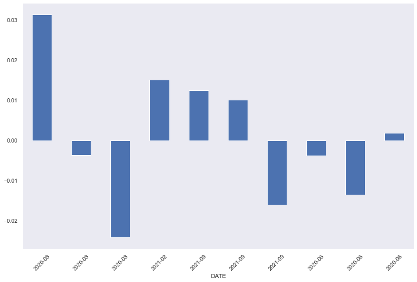

```python
# Plot the error term between the actual and predicted values for the last 10 months.

error.plot(kind='bar',figsize=(14,9))
plt.grid(which='major', linestyle='-', linewidth='0.5', color='green')
plt.grid(which='minor', linestyle=':', linewidth='0.5', color='black')
plt.xticks(rotation=45)
plt.show()
```

## 3.5 Find associations between categorical and target variable.

We are interested in how categorical independent variables (industry segment) relates to a normally distributed continuous (interval or ratio level) dependent variable. We want to see how the loss ratio changes per industry, and to what extent?

We apply groupby method and pass it in a column, to split the data into relevant groups, based on the criteria passed in. The reason for applying this method is to break a big data analysis problem into manageable parts. Then we can perform operations on the individual parts and put them back together. While the apply and combine steps occur separately, Pandas abstracts this and makes it appear as though it was a single step.

```python
# Return 'ACCOUNTING_MONTH' and categorical 'INDUSTRY' as new dataframe.
cat_df = df[['ACCOUNTING_MONTH', 'INDUSTRY', 'IL','EP']]
cat_df.head()
```

|  | ACCOUNTING_MONTH | INDUSTRY | IL | EP |
| --- | --- | --- | --- | --- |
| 0 | 2019-06-01 | Office | 49655.00 | 54566.04 |
| 1 | 2019-06-01 | Service | NaN | 49865.39 |
| 2 | 2019-06-01 | Office | 1617.32 | 8359.42 |
| 3 | 2019-06-01 | Service | NaN | 26468.31 |
| 4 | 2019-06-01 | Warehouse | NaN | 9538.47 |

```python
# Find the amount of segments in 'INDUSTRY'.
print(cat_df.groupby('INDUSTRY').groups.keys())
```

```
dict_keys(['Auto Service', 'Food Service', 'Hab', 'MOTEL', 'Office', 'Retail', 'Service', 'Warehouse'])
```

```python
# Filter only rows where positive values exist for premium.
seg_df = cat_df.groupby('INDUSTRY').filter(lambda g: any(g.INDUSTRY != 'MOTEL'))
seg_df
```

|  | ACCOUNTING_MONTH | INDUSTRY | IL | EP |
| --- | --- | --- | --- | --- |
| 0 | 2019-06-01 | Office | 49655.00 | 54566.04 |
| 1 | 2019-06-01 | Service | NaN | 49865.39 |
| 2 | 2019-06-01 | Office | 1617.32 | 8359.42 |
| 3 | 2019-06-01 | Service | NaN | 26468.31 |
| 4 | 2019-06-01 | Warehouse | NaN | 9538.47 |
| ... | ... | ... | ... | ... |
| 145646 | 2022-02-01 | Office | NaN | 0.00 |
| 145647 | 2022-02-01 | Food Service | NaN | 311.76 |
| 145648 | 2022-02-01 | Retail | NaN | 377.28 |
| 145649 | 2022-02-01 | Food Service | NaN | 0.00 |
| 145650 | 2022-02-01 | Service | NaN | 3814.36 |

140235 rows × 4 columns

```python
# Find total 'INCURRED LOSS', 'EARNED PREMIUM' for each month, industry using groupby, sum method.
seg1_df = seg_df.groupby(['ACCOUNTING_MONTH','INDUSTRY']).sum()
seg1_df
```

| ACCOUNTING_MONTH | INDUSTRY | IL | EP |
| --- | --- | --- | --- |
| 2019-05-01 | Auto Service | 5149602.64 | 8364819.91 |
|  | Food Service | 9636969.99 | 12840995.53 |
|  | Hab | 70484386.40 | 23839342.55 |
|  | Office | 8381541.91 | 12174835.47 |
|  | Retail | 13066738.35 | 13742639.32 |
| ... | ... | ... | ... |
| 2022-04-01 | Hab | 5539667.77 | 26603935.67 |
|  | Office | 1838625.68 | 13282333.60 |
|  | Retail | 3213044.60 | 17086574.38 |
|  | Service | 575902.90 | 2724571.87 |
|  | Warehouse | 516485.44 | 1559875.27 |

252 rows × 2 columns

```python
# Calculate 'LRATIO' into dataframe.
seg1_df['LRATIO'] = seg1_df.apply(lambda x : (x['IL']) / (x['EP']), axis = 1)
seg1_df
```

| ACCOUNTING_MONTH | INDUSTRY | IL | EP | LRATIO |
| --- | --- | --- | --- | --- |
| 2019-05-01 | Auto Service | 5149602.64 | 8364819.91 | 0.615626 |
|  | Food Service | 9636969.99 | 12840995.53 | 0.750485 |
|  | Hab | 70484386.40 | 23839342.55 | 2.956641 |
|  | Office | 8381541.91 | 12174835.47 | 0.688432 |
|  | Retail | 13066738.35 | 13742639.32 | 0.950817 |
| ... | ... | ... | ... | ... |
| 2022-04-01 | Hab | 5539667.77 | 26603935.67 | 0.208227 |
|  | Office | 1838625.68 | 13282333.60 | 0.138426 |
|  | Retail | 3213044.60 | 17086574.38 | 0.188045 |
|  | Service | 575902.90 | 2724571.87 | 0.211374 |
|  | Warehouse | 516485.44 | 1559875.27 | 0.331107 |

252 rows × 3 columns

```python
# Pivot dataframe to show 'LRATIO' by industry using unstack method.
seg2_df = seg1_df['LRATIO'].unstack()
seg2_df.head()
```

| INDUSTRY ACCOUNTING_MONTH | Auto Service | Food Service | Hab | Office | Retail | Service | Warehouse |
| --- | --- | --- | --- | --- | --- | --- | --- |
| 2019-05-01 | 0.615626 | 0.750485 | 2.956641 | 0.688432 | 0.950817 | 0.640479 | 1.259127 |
| 2019-06-01 | 0.753519 | 0.786839 | 0.297723 | 0.609221 | 0.703595 | 0.619689 | 2.006241 |
| 2019-07-01 | 0.765420 | 0.658896 | 0.348342 | 0.750962 | 0.927765 | 0.364419 | 0.561708 |
| 2019-08-01 | 0.740779 | 0.837329 | 0.413033 | 0.417715 | 0.537544 | 0.677148 | 0.154047 |
| 2019-09-01 | 0.553436 | 0.498910 | 0.295809 | 0.429989 | 0.494777 | 0.341039 | 1.954000 |

### Observation.

After performing several manipulations by pivoting dataframe, we find totals of loss ratios per each industry. Now, we can visualize trends across time.

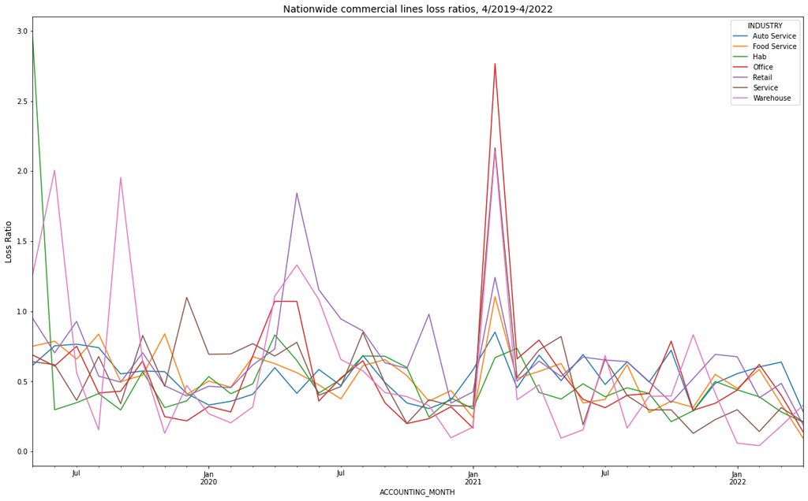

```python
# Plot data to show time trend 'LRATIO' per 'INDUSTRY'.
fig, ax = plt.subplots(figsize = (20,12))
plt.xlabel('Date')
plt.ylabel('Loss Ratio', size=12)
plt.title('Nationwide commercial lines loss ratios, 4/2019-4/2022', size=14)
seg2_df.plot(ax = ax)
```

### Observation.

We find there is an overall trend of loss ratios down, with isolated large spikes in Habitational, Warehouse losses incurred in 2019-2020. In early 2021, almost all segments spiked with incurred losses. In 2022, besides the warehouse segment, all loss ratios are trending lower. Below is a link for an interactive dashboard using Tableau:

https://public.tableau.com/views/TrendsforBOPData2019-Present/Dashboard1?:language=en-US&:display_count=n&:origin=viz_share_link

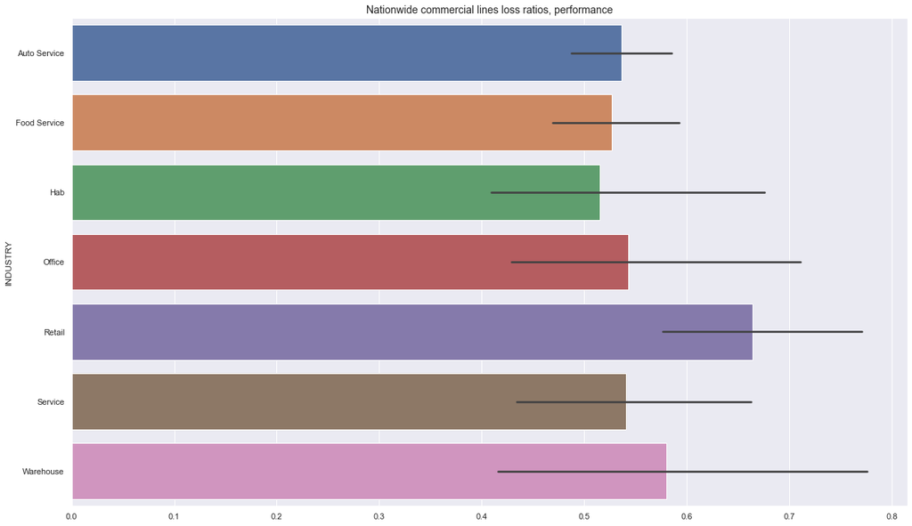

```python
# Plot total 'LRATIO' per 'INDUSTRY' performance and confidence interval using seaborn barplot.
import seaborn as sns
sns.set(rc = {'figure.figsize':(20,12)})
plt.title('Nationwide commercial lines loss ratios, performance', size=14)
ax = sns.barplot(data=seg2_df, orient = 'h')
```

### Observation.

We find that across a span of 3 years, the loss ratio performance is mostly between 52-58% (67% for retail), which is profitable for Nationwide. The black lines indicate 95% confidence intervals, where the largest spread of losses incurred is in the warehouse segment.

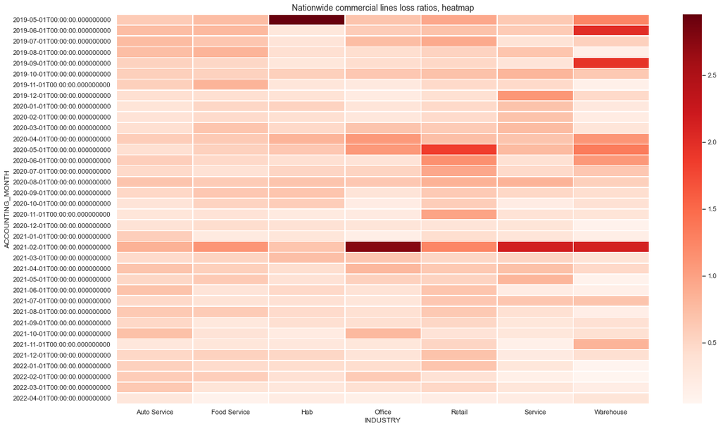

```python
# Plot Seaborn heatmap to show 'LRATIO' per 'INDUSTRY'.
plt.figure(figsize = (20,12))
sns.heatmap(seg2_df, cmap="Reds", linewidths=.6)
plt.title('Nationwide commercial lines loss ratios, heatmap', size=14)
plt.show()
```

# 4. Summarize model for recommendations.

We explored data from a time series of numerical and categorical variables of commercial insurance data, from mid-2019 to mid-2022. Our target variable loss ratio, a percentage of incurred loss to earned premium. In this data, several numeric variables were found to vary in scales and type. We normalized to this data and then calculated linear regression from trained data, relating independent variables, discovering a high correlation between loss incurred and loss ratio.

We also looked at categorical industry segment, and upon modeling time series and plots, discovered an overall downtrend in loss ratios over time. As the majority of segments are under 70%, this implies healthy profitability. The poorer performing segments are retail, warehouse (profit < 45%). The higher performing segments are in auto and food service, habitational, office and service (profit >45%).